# Los sectores mas influyentes dentro de las 500 empresas más importantes de México

### Aldo Aviles Aguilar

Fecha: 2020-08-01

[figure not shown]

Cada año, la revista “Expansión” publica un ranking con las empresas con más utilidades en el periodo, ilustrando la influencia que tienen en la economía mexicana y exponiendo, entre otros aspectos, la importancia del sector de los servicios y el desplazamiento del sector primario (Agricultura, Ganadería, etc.) dentro de la producción interna.

Con base en el artículo publicado en la revista “Expansion”(https://expansion.mx/las-500) y a la base de datos divulgada por la misma, se realizó un ejercicio estadístico, en el que se segmentó a cada uno de los sectores que estuvieron en este ranking.

Se analizó la base de las 500 Empresas y se obtuvo la participación porcentutal de cada una respecto al total, para saber su aportación y proporción. Para determinar los sectores, en el listado de empresas inicialmente viene en una tabla con Número de Rankig, Empresa y Sector al que pertenece y ventas en millones, pero para fines del artículo, solo se tomaron en cuenta las variables que se muestran en la tabla.

|  | Sector | N..de.Empresas | Proporción | Aportación |
| --- | --- | --- | --- | --- |
| 1 | Aerolíneas | 4 | 0.008 | 0.8 |
| 2 | Afore | 4 | 0.008 | 0.8 |
| 3 | Agroindustria | 2 | 0.004 | 0.4 |
| 4 | Alimentos | 27 | 0.054 | 5.4 |
| 5 | Armadora | 18 | 0.036 | 3.6 |
| 6 | Automotriz y Autopartes | 34 | 0.068 | 6.8 |
| 7 | Bebidas y Cerveza | 13 | 0.026 | 2.6 |
| 8 | Cemento y Materiales | 6 | 0.012 | 1.2 |
| 9 | Comercio Autoservicio | 14 | 0.028 | 2.8 |
| 10 | Comerio de Medicamentos | 4 | 0.008 | 0.8 |

[output cut: 36 more lines]

Como contraste, los 10 sectores que menos aportan a la economía, son Restaurantes, Tecnología Diversificada, Entretenimiento, Juegos y Sorteos, Medios, Servicios de Salud, Agroindustria, Cuidado Personal, Suplementos Alimenticios, Tabaco y Vidrio y Envases, concentrando únicamente el 6 % del total de las empresas. Esto evidencía la poca diversificación y desarrollo que hay en los sectores basados en el entretenimiento y de cuidado personal, y aún más importante en los Servicios de Salud y la Agroindustria, señalando así, un preocupante sesgo en estos sectores que deberían ser primordiales en la economía mexicana y sobre todo para el desarrollo del país.

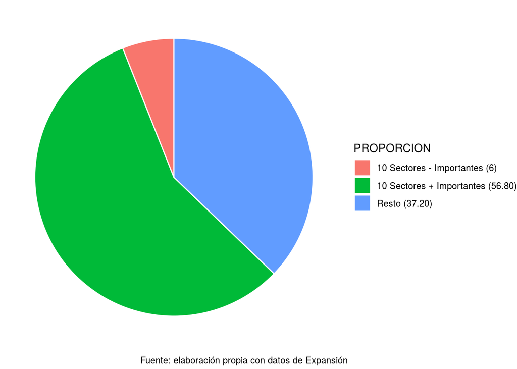

[Tweet](https://twitter.com/share?ref_src=twsrc%5Etfw)

[interactive chart not shown]

> Este artículo fue generado mediante R en August 01, 2020 y forma parte de las actividades realizadas en las materias de Estadística y Taller IV. Facultad de Economía, Ciudad Universitaria. Contacto: contacto.estadistica.practica@gmail.com. Creative Commons (CC).  
> Esta obra está bajo una [licencia de Creative Commons Reconocimiento-NoComercial-CompartirIgual 4.0 Internacional.](http://creativecommons.org/licenses/by-nc-sa/4.0/)